# Red Wine Analysis by Manish Kumar

### Plot Three

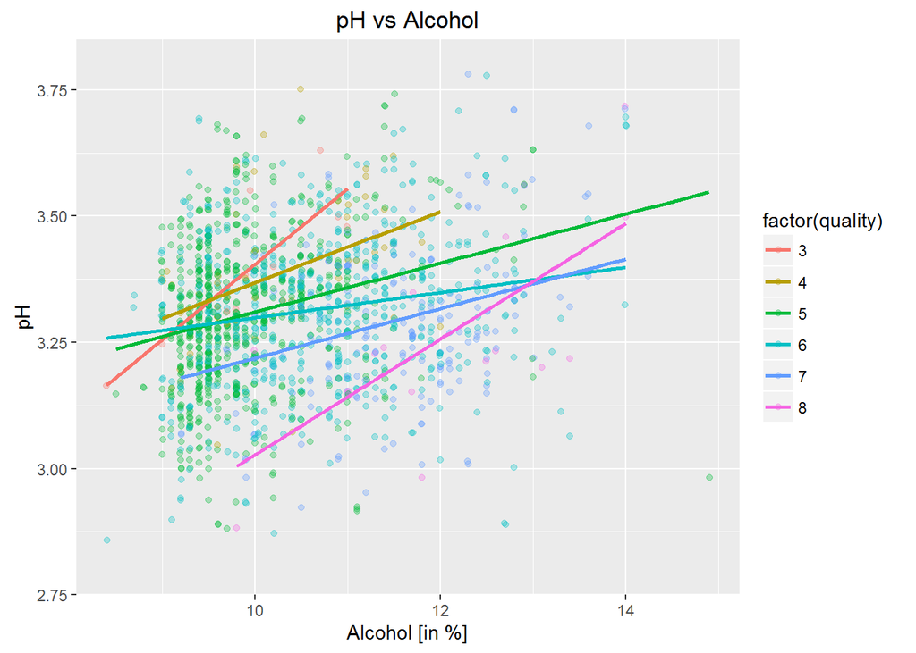

### Description Three

This is the most important plot as it includes both variables that affect wine the most and those are Alcohol content in wine and pH value which intern represent the amount of acidity in wine. low quality wine has more pH which means less acidic and high quality wine tend to have less pH which means acidic wine in nature. Alcohol also affecting the wine higher the alcohol means more quality.

# Reflection

The dataset has 1599 observations and on the basis of these observation i tried to explore the dataset to know information about the red wine. I started working on this dataset and tried to find how many wines contains how much value of variable. For example i want to know how number of wine varies with the quality.How many wines have quality of 8 and how many have quality of 3.So i created histogram for every variable and This gave me a lot of information about the dataset and type of values. Before creating every variable histogram i tried to create a unified plot which should contain all variables histogram but It would be hard and lengthy if i try to make individual plot and then make the unified plot using grid_extra package so i firstly converted dataset into tidy format with two columns one contains variable and other contains values and then it would be very easy i used facet wrap function on the variable column of new dataset which made a unified plot with 4 lines of code.

From this one variable analysis i only got information about the dataset but i want to explore more so i started to explore two variables or bi variate analysis. I was more interested in the quality of wine and want to know how it varies with the variation in the other variables. for example how the quality changes with the change in alcohol content in wine or how quality of wine changes with the change in the acidity of the wine.Will Quality of wine increase with the increase in acidity or not?

So for that i created scatter plot of variables which have high correlation coefficient with quality.I also plotted box plot along with scatter plot so that the statistical values are also visible like mean. From these plot i get to know that increase in alcohol result in the increase in quality.Also the increase in acidity of wine means that increase in quality of wine.

But what about the combination of variable How do we know the variation of two variable simultaneously with the quality.So for this comes the multivariate analysis. My most interesting plot was variation of quality with the variation of pH and alcohol. As i already know from bi variate analysis that the acidity means pH and alcohol are the main variables which affect the quality of wine.So i plotted the scatter plot of pH vs Alcohol and the color of points is the quality which gave me the variation of quality with both acidity and alcohol.

The following are the things i get to know after exploring it:-

1. High quality wine has more alcohol.
2. The increase in acidity results in the good quality alcohol. May be this is because the people like the acidic taste.
3. volatile acidity is different from fixed acidity or we can say they are inverse of each other if one increases then the other decreases